# Which year were the best popular movies made?

Daniel Dittenhafer

Tuesday, September 16, 2014

Which year were the best popular movies made? 1987? 2002? 1955? Using R and a [dataset provided by Hadley Wickham](http://had.co.nz/data/movies/), I have come to a conclusion. But first let me describe my process.

The data set, originally from [IMDB.com](http://IMBD.com/), provides a variety of data points about each movie going back as far as 1893 (but is current only through 2005). Some data points of interest include IMDB user rating, the number of rating votes cast, the budget for making the film, genre and MPAA rating.

Given that this data set comes originally from IMDB.com, an internet website, the user ratings are most likely biased to those movies for which internet users find compelling in some way. With that acknowledged, lets proceed.

My approach is to use the `votes` data point as a proxy for popularity. Hopefully this is intuitive, but the concept is that if a movie is popular, good or bad, it will receive more votes.

The following code illustrates loading the data set and massaging the data to tease out the number of movies and votes cast per year. I divide the total votes per year by the number of movies in the year as a technique to normalize against years with more movies and potentially more votes as a result.

```r
# Load the movie data set
movies <- read.table("C:/SourceCode/R/DataAcqMgmt/MovieData/movies.tab", sep="\t", header=TRUE, quote="", comment="")

# Group by year and sum votes
votesByYear <- aggregate(votes ~ year, movies, sum)

# Using plyr::count to determine movies/yr
moviesByYear <- plyr::count(movies, "year")
moviesVotesByYear <- merge(votesByYear, moviesByYear, by="year")

# Divide votes by # movies in the year to account for years with more
# movies contributing to more total votes
avgVotesPerMovie <- moviesVotesByYear$votes / moviesVotesByYear$freq
moviesVotesByYear <- cbind(moviesVotesByYear, avgVotesPerMovie)

# Sort votes descending and grab the 10 years with most votes
votesByYearSorted <- moviesVotesByYear[order(-moviesVotesByYear$avgVotesPerMovie), ]
mostPopularByVote <- votesByYearSorted[1:10, ]

print(mostPopularByVote)
```

```
##     year   votes freq avgVotesPerMovie
## 107 1999 2630297 1927             1365
## 103 1995 1514866 1248             1214
## 105 1997 1841148 1568             1174
## 102 1994 1374580 1199             1146
## 106 1998 1909962 1705             1120
## 101 1993 1117554 1016             1100
## 109 2001 2263362 2121             1067
## 108 2000 2173392 2048             1061
## 104 1996 1455862 1390             1047
## 110 2002 2270605 2168             1047
```

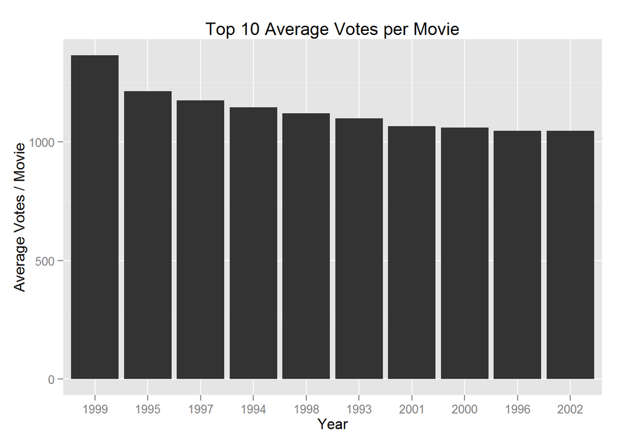

Now that we have a list of candidate years with popular movies, the `rating` data point can be brought in as a proxy for “best”.

```r
avgRatings <- aggregate(rating ~ year, movies, mean)
popMoviesAvgRating <- subset(avgRatings, year %in% mostPopularByVote$year, year:rating)
popMoviesAvgRating <- popMoviesAvgRating[order(-popMoviesAvgRating$rating), ]
print(popMoviesAvgRating)
```

```
##     year rating
## 110 2002  6.284
## 109 2001  6.101
## 108 2000  5.934
## 106 1998  5.858
## 104 1996  5.747
## 103 1995  5.739
## 107 1999  5.637
## 101 1993  5.593
## 102 1994  5.492
## 105 1997  5.394
```

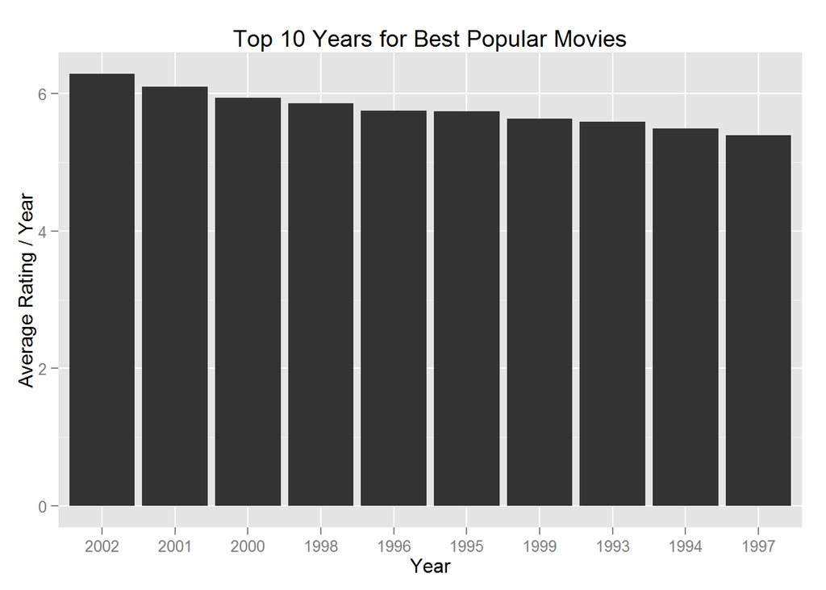

Based on the analysis described above, the year 2002 appears to be the year when the best popular movies were made. Using the following R code, I will extract the specific list of the best popular movies.

```r
# Extract movies for the specific year and sort by votes and rating
moviesIn2002 <- subset(movies, year == 2002, c("title", "votes", "rating"))
moviesIn2002Sorted <- moviesIn2002[order(-moviesIn2002$votes, -moviesIn2002$rating),]

# Pull out top 10
top10MoviesIn2002 <- data.frame(moviesIn2002Sorted[1:10,])
```

[output not shown]

Links I found useful while working this assignment:

- [StackOverflow: How to Change the Order of a Discrete X Scale in ggplot](http://stackoverflow.com/questions/3253641/how-to-change-the-order-of-a-discrete-x-scale-in-ggplot)

Best,

Daniel